# PML Fitness Assignment

## Random Forest Model

A random forest model is used with 5-fold cross validaion, the 46 features from recursive feature elimination and a specified grid to tune to: mtry = number of variables to sample at each split. The features have normalised using the built in scale and centre options.

```r
# Select the variables selected from RFE
train_temp <- cbind(train[rfProfile$optVariables], classe = train$classe)

tunegrid <- expand.grid(.mtry = c(2:6, seq(7,ncol(train_temp), by = 3)))

train_ctrl <- trainControl (
  classProbs=TRUE,
  search = "grid",
  savePredictions=TRUE,
  # Use Cross Validation
  method = "cv",
  # Use 5 folds
  number = 5,
  repeats = 5,
  allowParallel = TRUE)

system.time(
  model_fit <- train(
  classe ~ .,
  method = "rf",
  preProcess = c("center", "scale"),
  trControl = train_ctrl,
  tuneGrid=tunegrid,
  data = train_temp)
)
```

```
##    user  system elapsed
##   47.24    1.28 2336.80
```

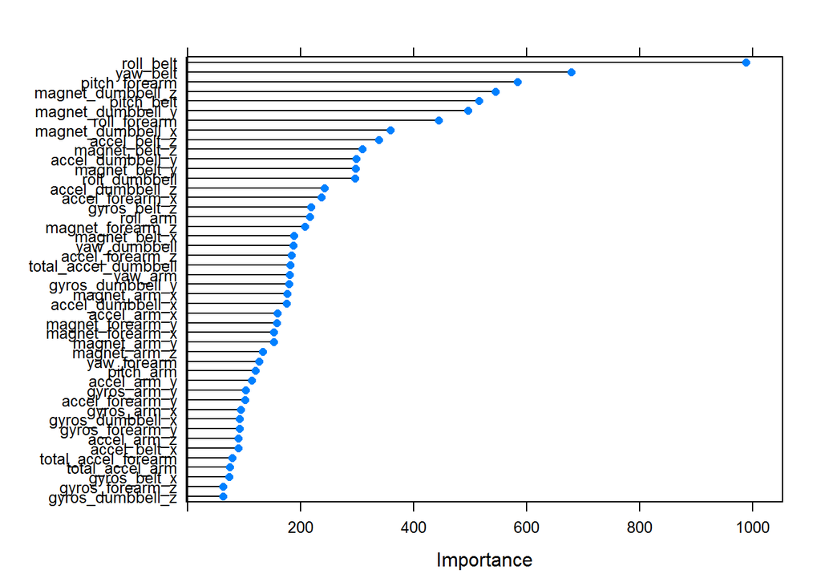

```r
# Stop the parallel cluster
stopCluster(cl)

importance <- varImp(model_fit, scale=FALSE)

# plot importance
plot(importance)
```

```r
print(model_fit, digits = 3)
```

```
## Random Forest
##
## 13737 samples
##    46 predictor
##     5 classes: 'A', 'B', 'C', 'D', 'E'
##
## Pre-processing: centered (46), scaled (46)
## Resampling: Cross-Validated (5 fold)
## Summary of sample sizes: 10990, 10989, 10988, 10990, 10991
## Resampling results across tuning parameters:
##
##   mtry  Accuracy  Kappa
##    2    0.992     0.990
##    3    0.993     0.991
##    4    0.993     0.992
##    5    0.993     0.992
##    6    0.993     0.992
##    7    0.994     0.992
##   10    0.993     0.992
##   13    0.993     0.991
##   16    0.993     0.991
##   19    0.993     0.991
##   22    0.993     0.991
##   25    0.992     0.990
##   28    0.992     0.989
##   31    0.991     0.988
##   34    0.990     0.987
##   37    0.990     0.987
##   40    0.989     0.987
##   43    0.989     0.986
##   46    0.989     0.986
##
## Accuracy was used to select the optimal model using  the largest value.
## The final value used for the model was mtry = 7.
```

The model shows a good fit over the training set with accuracy over 98% for all values of mtry. Now to see how it compares over the test set.

```r
prediction <- predict(model_fit, newdata = test)

confusion <- confusionMatrix(prediction, test$classe)

print(confusionMatrix(prediction, test$classe), digits=3)
```

```
## Confusion Matrix and Statistics
##
##           Reference
## Prediction    A    B    C    D    E
##          A 1674    7    0    0    0
##          B    0 1131    5    0    0
##          C    0    1 1021    5    0
##          D    0    0    0  958    0
##          E    0    0    0    1 1082
##
## Overall Statistics
##
##                Accuracy : 0.997
##                  95% CI : (0.995, 0.998)
##     No Information Rate : 0.284
##     P-Value [Acc > NIR] : <2e-16
##
##                   Kappa : 0.996
##  Mcnemar's Test P-Value : NA
##
## Statistics by Class:
##
##                      Class: A Class: B Class: C Class: D Class: E
## Sensitivity             1.000    0.993    0.995    0.994    1.000
## Specificity             0.998    0.999    0.999    1.000    1.000
## Pos Pred Value          0.996    0.996    0.994    1.000    0.999
## Neg Pred Value          1.000    0.998    0.999    0.999    1.000
## Prevalence              0.284    0.194    0.174    0.164    0.184
## Detection Rate          0.284    0.192    0.173    0.163    0.184
## Detection Prevalence    0.286    0.193    0.175    0.163    0.184
## Balanced Accuracy       0.999    0.996    0.997    0.997    1.000
```

The prediction for the test set is very good with sensitivity, specificity and accuracy all over 99%. The model should generalise well over the 20 sample test set.

## Out of sample error

The out of sample error is the error rate from applying the model to predict over data that was not used in the training, in this case *test*. This yielded an out of sample error of 0.0032285.

# Prediction over Project Test set

This project has a set of 20 cases that are required to be predicted using the trained model. The values for the prediction are below:

```r
prediction <- predict(model_fit, newdata = validation)

prediction
```

```
##  [1] B A B A A E D B A A B C B A E E A B B B
## Levels: A B C D E
```

End of assignment.

# Appendix - Summary Statistics

```r
summary(original_sample)
```

[output not shown]

[output cut: 313 more lines]

[output not shown]